# Understanding GDP and Educational Factors from World Bank Data

Dennis Murray

June 10, 2016

### Introduction

The World Bank is an international financial organization with the stated objective of ending world poverty, and promoting shared poverty. (Source: Worldbank.org)

Accompanying this mission, the Bank also collects data about the national economies and incomes of countries in all parts of the world. This provides a clearinghouse of objectively collected data about each country, and the economic status of their citizens.

Our data set for this review is comprised of two pieces.

The first provides the Gross Domestic Product (GDP) of 190 countries. Gross Domestic Product is defined by the World Bank as “sum of gross value added by all resident producers in the economy plus any product taxes and minus any subsidies not included in the value of the products.”

The second data source from the World Bank provides a host of demographic data regarding the income of the citizens of each country.

This report will seek to find and explain the relationships between several of these variables, and the differences among GDP between countries.

### Data Import, Cleaning and Merging

We will require several packages within R to load, process, and visualize the data from the World Bank. These include dplyr, repmis and ggplot2.

```r
source("Analysis/Environment.R", echo=TRUE)
```

```
##
## > library(repmis)
##
## > library(dplyr)
```

```
##
## > library(ggplot2)
```

We will begin by downloading, and then loading to the R environment, each of the data files from the World Bank.

```r
source("Analysis/LoadData.R", echo=TRUE)
```

```
##
## > GDPurl <- "https://d396qusza40orc.cloudfront.net/getdata%2Fdata%2FGDP.csv"
##
## > EDUurl <- "https://d396qusza40orc.cloudfront.net/getdata%2Fdata%2FEDSTATS_Country.csv"
##
## > setwd("~/R/6306CaseStudyWeek6/Data")
##
## > download.file(GDPurl, "GDP.csv")
##
## > download.file(EDUurl, "education.csv")
##
## > GDP <- read.csv("GDP.csv", skip = 5, header = FALSE)
##
## > EDU <- read.csv("education.csv", header = TRUE)
```

First we will clean up the table with the GDP data and provide column names that are tidy and more descriptive.

```r
source("Analysis/CleanData1.R", echo=TRUE)
```

```
##
## > setwd("~/R/6306CaseStudyWeek6")
##
## > names(GDP) <- c("CountryCode", "GDPRank", "Blank",
## +     "CountryName", "GDPDollarsMM2012")
##
## > GDP$GDPDollarsMM2012 <- gsub(",", "", GDP$GDPDollarsMM2012)
##
## > GDP$GDPDollarsMM2012 <- as.numeric(GDP$GDPDollarsMM2012)
```

```
##
## > GDPcut <- GDP[1:216, ]
##
## > GDPcut$GDPRank <- as.character(GDPcut$GDPRank)
##
## > GDPcut$GDPRank <- as.numeric(GDPcut$GDPRank)
##
## > GDPFinal <- data.frame(GDPcut$CountryCode, GDPcut$GDPRank,
## +     GDPcut$CountryName, GDPcut$GDPDollarsMM2012)
##
## > names(GDPFinal) <- c("CountryCode", "GDPRank", "CountryName",
## +     "GDPDollarsMM2012")
##
## > GDPFinal <- GDPFinal[GDPFinal$CountryCode != "", ]
##
## > GDPFinal <- GDPFinal[order(-GDPFinal$GDPDollarsMM2012),
## +     ]
```

Next we will clean up the table with the Education and Income data, and provide cleaner and more descriptive field names.

```r
source("Analysis/CleanData2.R", echo=TRUE)
```

```
##
## > EDUFinal <- data.frame(EDU$CountryCode, EDU$Long.Name,
## +     EDU$Income.Group, EDU$Region)
##
## > names(EDUFinal) <- c("CountryCode", "LongName", "IncomeGroup",
## +     "Region")
```

### Question 1: Match the data based on the country shortcode. How many of the IDs match?

First, we will merge the two files together using the Country code as a key field in each table.

```r
source("Analysis/MergeData.R", echo=TRUE)
```

```
##
## > EducationGDP <- full_join(EDUFinal, GDPFinal, by = "CountryCode")
```

```r
source("Analysis/Question1.R", echo=TRUE)
```

```
##
## > CompleteRecords <- EducationGDP$CountryCode[!is.na(EducationGDP$CountryName) &
## +     !is.na(EducationGDP$LongName)]
##
## > print(length(CompleteRecords))
## [1] 210
```

The join gave us 210 complete records - with definition of complete here meaning instances where both the Long Name (from the Education data) and the Country Name (from the GDP data) are populated for the record, indicating a successful join.

### Question 2: Sort the data frame in ascending order by GDP rank (so United States is last.) What is the 13th country in the resulting data frame?

First, we will sort the combined data frame on ascending order and then retrieve the 13th ranked country.

```r
source("Analysis/Question2.R", echo=TRUE)
```

```
##
## > EducationGDP <- EducationGDP[order(EducationGDP$GDPDollarsMM2012),
## +     ]
##
## > head(EducationGDP, 10)
##     CountryCode                                     LongName
## 214         TUV                                       Tuvalu
## 108         KIR                         Republic of Kiribati
## 138         MHL             Republic of the Marshall Islands
## 170         PLW                            Republic of Palau
## 195         STP Democratic Republic of São Tomé and Principe
## 70          FSM               Federated States of Micronesia
## 210         TON                             Kingdom of Tonga
## 51          DMA                     Commonwealth of Dominica
## 42          COM                         Union of the Comoros
```

[output cut: 27 more lines]

After sorting the data in ascending GDP Rank Order, we can see the lowest country, Tuvalu, is in the first row of the data frame.

St. Kitts and Nevis is the 13th ranked country, with 767 million dollars in GDP in 2012.

Second, we will find the number of values where there is no value for the Gross Domestic Product.

```r
source("Analysis/Question2a.R", echo=TRUE)
```

```
##
## > sum(is.na(EducationGDP$GDPDollarsMM2012))
## [1] 48
```

There are 48 instances of missing value in the GDP field.

### Question 3: What are the average GDP rankings for the “High income: OECD” and “High income: nonOECD” groups?

```r
source("Analysis/Question3.R", echo=TRUE)
```

```
##
## > tapply(EducationGDP$GDPRank, EducationGDP$IncomeGroup,
## +     mean, na.rm = TRUE)
##                      High income: nonOECD    High income: OECD
##                  NaN             91.91304             32.96667
##           Low income  Lower middle income  Upper middle income
##            133.72973            107.70370             92.13333
##
## > tapply(EducationGDP$GDPRank, EducationGDP$IncomeGroup,
## +     sd, na.rm = TRUE)
##                      High income: nonOECD    High income: OECD
##                   NA             42.68799             27.54868
##           Low income  Lower middle income  Upper middle income
##             29.65135             54.19136             56.51010
```

```r
source("Analysis/Question3a.R", echo=TRUE)
```

```
##
## > sum(!complete.cases(data.frame(EducationGDP$IncomeGroup,
## +     EducationGDP$GDPRank)))
## [1] 49
```

There are 49 instances of missing either the GDP rank, or the Income Group.

### Question 4: Plot the GDP for all of the countries. Use ggplot2 to color your plot by Income Group.

```r
source("Analysis/Question4.R", echo=TRUE)
```

```
##
## > EducationGDPClean <- data.frame(EducationGDP$CountryCode,
## +     EducationGDP$GDPDollarsMM2012, EducationGDP$IncomeGroup)
##
## > names(EducationGDPClean) <- c("CountryCode", "GDPDollarsMM2012",
## +     "IncomeGroup")
##
## > EducationGDPClean <- EducationGDPClean[!is.na(EducationGDPClean$GDPDollarsMM2012),
## +     ]
##
## > p <- ggplot(data = EducationGDPClean, aes(reorder(CountryCode,
## +     GDPDollarsMM2012), y = GDPDollarsMM2012))
##
## > p + geom_point(aes(colour = IncomeGroup)) + labs(title = "GDP by Country",
## +     y = "2012 GDP, $MM", x = "Country Code")
```

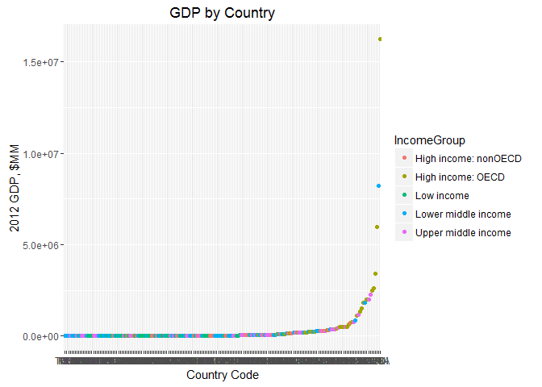

Most of the top ranked countries are in the highest income groups, with the notable of exception of the second ranked country, China.

If we remove the top 15 countries from the visualization, and replot again, a greater amount of the variability Gross Domestic Product of the countries ranked 16-190 in the world. It also appears that most of the lower GDP countries fall into the “Lower Middle Income” or “Low Income” groups, but there are a few higher income countries in the lower tiers.

```r
source("Analysis/Question4b.R", echo=TRUE)
```

```
##
## > library(ggplot2)
##
## > EducationGDPCleanLow <- data.frame(EducationGDP$CountryCode,
## +     EducationGDP$GDPDollarsMM2012, EducationGDP$IncomeGroup,
## +     EducationGDP$GDP .... [TRUNCATED]
##
## > names(EducationGDPCleanLow) <- c("CountryCode", "GDPDollarsMM2012",
## +     "IncomeGroup", "GDPRank")
##
## > EducationGDPCleanLow <- EducationGDPCleanLow[!is.na(EducationGDPCleanLow$GDPDollarsMM2012),
## +     ]
##
## > EducationGDPCleanLow <- EducationGDPCleanLow[EducationGDPCleanLow$GDPRank >
## +     15, ]
##
## > pl <- ggplot(data = EducationGDPCleanLow, aes(reorder(CountryCode,
## +     GDPDollarsMM2012), y = GDPDollarsMM2012))
##
## > pl + geom_point(aes(colour = IncomeGroup)) + labs(title = "GDP by Country",
## +     y = "2012 GDP, $MM", x = "Country Code")
```

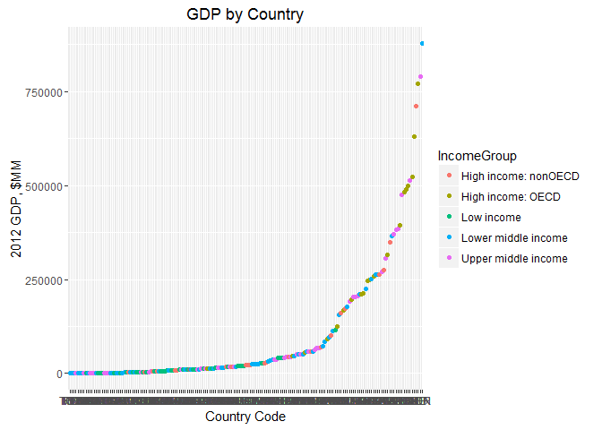

```r
source("Analysis/Question4a.R")
```

The visualization of the GDP by Country excludes 48 countries that have no value available for GDP.

### Question 5: Cut the GDP ranking into 5 separate quantile groups. Make a table versus Income.Group. How many countries are Lower Middle income but among the 38 nations with highest GDP?

```r
source("Analysis/Question5.R", echo=TRUE)
```

```
##
## > GDPSub <- data.frame(EducationGDP$GDPDollarsMM2012,
## +     EducationGDP$CountryCode, EducationGDP$IncomeGroup)
##
## > GDPSub <- GDPSub[complete.cases(GDPSub), ]
##
## > GDPQuantile <- data.frame(ntile(GDPSub$EducationGDP.GDPDollarsMM2012,
## +     n = 5), GDPSub$EducationGDP.GDPDollarsMM2012, GDPSub$EducationGDP.Count .... [TRUNCATED]
##
## > names(GDPQuantile) <- c("Quantile", "GDP", "CountryCode",
## +     "IncomeGroup")
##
## > CrossGDP <- xtabs(~GDPQuantile$Quantile + GDPQuantile$IncomeGroup)
##
## > CrossGDP
##                     GDPQuantile$IncomeGroup
## GDPQuantile$Quantile    High income: nonOECD High income: OECD Low income
##                    1  0                    2                 0         11
##                    2  0                    4                 1         16
##                    3  0                    8                 1          9
##                    4  0                    5                10          1
##                    5  0                    4                18          0
##                     GDPQuantile$IncomeGroup
## GDPQuantile$Quantile Lower middle income Upper middle income
##                    1                  16                   9
##                    2                   9                   8
##                    3                  11                   9
##                    4                  14                   8
##                    5                   4                  11
```

```r
source("Analysis/Question5a.R", echo=TRUE)
```

```
##
## > sum(!complete.cases(EducationGDP$GDPDollarsMM2012,
## +     EducationGDP$CountryCode, EducationGDP$IncomeGroup))
## [1] 49
```

There are 49 countries with an empty value in either GDP or Income Group.

### Conclusions

The World Bank data provides insights into the Gross Domestic Product, as well as qualitative data about the countries of the world.

Further investigation into the subject could take the path of examining the income classifications in further depth, or developing a more quantitative measure for income.